# Fundamentos de Testing

Ingenieria de Software Python Tesing Programacion Workshop

El testing es uno de los procesos de la ingeniería de software que permite identificar defectos en el software En este post podes encontrar los fundamentos para poder realizalo de manera practica en cualquier proyecto de desarrollo.

Romina Mendez , true  
02-21-2021

# Que es Testing?

El proceso de testing es la realización de pruebas tecnicas con el objetivo de poder conocer cual es la calidad de los artefactos. Estos procesos son una disciplina de la ingenieria de software y nos permiten realizar la validación y verificación de un software.

La validación y la verificación muchas veces se lo asocia a terminos similares, pero estos conceptos existen diferencias entre los mismos:

- Validaciòn: ¿estamos construyendo el producto correcto? “El producto satisface los requerimientos del usuario.”
- Verificación: ¿estamos construyendo el producto correctamente? “Controlar que el producto conforma su especificacion inicial, lo que significa que el software cumple con los requisitos funcionales y no funcionales.”

Es importante destacar que a pesar de realizar este proceso nunca va ser posible demostrar que el software esta libre de defectos, pero si vamos a poder eliminar gran parte de ellos y mitigar los riesgos que pueden producir los mismos.

# Por qué el testing es importante…

El softwares es un factor que permite a la industias poder gestionar, controlar y automatizar sus procesos. La industria 4.0 nos impulsa a cambios en el cual las organizaciones utilizar sistemas para la produccion utilizando tecnologias basadas en información tales como: machine learning, big data, Cloud Computing y IOT.

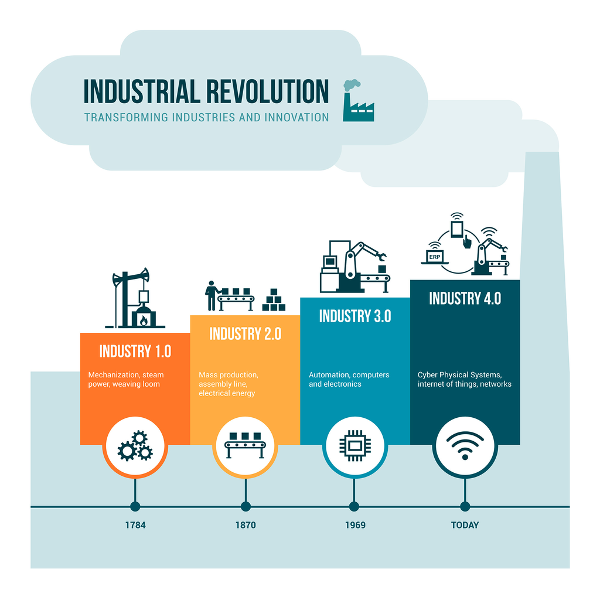

[^1]

La calidad del software en la automatización industrial es un factor clave que debe ser abordado para evitar tener daños o perdidas economicas para las empresas.

Actualmente los sistemas estan en cada una de las industrias, como se pueden ver en la siguiente imagen:

[figure not shown]

# Que es la calidad de software?

Según la definición que se encuentra en el Glosario estándar de terminología de ingeniería de software de IEEE:

El grado en que un sistema, componente o proceso cumple con los requisitos especificados.

El grado en que un sistema, componente o proceso satisface las necesidades o expectativas del cliente o usuario.

# Error -Defectos - Fallos

Muchas veces los terminos parecen similares, pero cada uno de ellos tienen un significado difente. Por lo cual podriamos definirlo como:

Un **`Error`** de un desarrollador, causa un **`Defecto`** en el software, lo cual provoca un **`Fallo`** en el momento en el que la prueba se ejecuta.

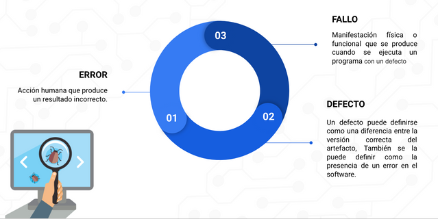

# Pruebas

Las pruebas de software son una estrategia de gestión del riesgo, en las mismas se evalúan si se cumplieron los requisitos y se buscan defectos.

Las pruebas son el proceso por el cual se verifica un componente de software para detectar la diferencia entre las condiciones existentes y las requeridas.

Aunque también la idea de realizar pruebas es conocer cuál es la calidad del software, evaluando la usabilidad, rendimiento, mantenimiento, accesibilidad, etc.

# 7 principios del proceso de testing

International Software Testing Qualifications Board (ISTQB) es el comité Internacional de Certificaciones de Pruebas de Software.

ISTQB desarrollo 7 principios para ayudar a como realizar el proceso de testing, estos son:

- 1️⃣Las pruebas muestran la presencia de los defectos.
- 2️⃣️No es posible realizar pruebas exhaustiva.
- 3️⃣Pruebas tempranas.
- 4️⃣Agrupamiento de los defectos.
- 5️⃣Paradoja de los pesticidas.
- 6️⃣Las pruebas dependen del contexto.
- 7️⃣La Falacia de la Ausencia de errores.

## 2️⃣️No es posible realizar pruebas exhaustiva

Es imposbile realizar todas las combinaciónes posibles para hacer pruebas, debido a esto es importante asumir un nivel de riesgo para poder priorizar las pruebas. Este punto es importante evaluarlo cuando se realizar la estrategia del plan de pruebas.

## 3️⃣Pruebas temprana

Es importante poder detectar las incidencias en las fases más tempranas de desarrollo. “Un defecto es más costoso de arreglar, cuanto más tarde es hallado.”

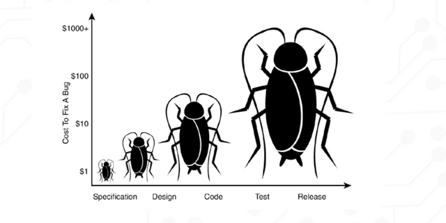

## 4️⃣Agrupamiento de los defectos.

Este principio significa que muchas veces los defectos pueden concentrarse en un determinado modulo del producto. Esto nos permite concentrar las pruebas en estos modulos, por lo cual es importante conocer cual son estos modulos en el momento que se diseña el plan de pruebas.

## 5️⃣Paradoja de los pesticidas.

Si siempre realizamos los mismos test no vamos a encontrar nuevos defectos, por lo cual es importante realizar una actualización de las pruebas a realizar. Este punto es importante ya que el software siempre esta en constante evolución y es bueno mantenerse actualizado con las pruebas que son necesarias a realizar.

## 6️⃣Las pruebas dependen del contexto.

Si bien pueden haber software similares, la estrategia de testing se debe adaptar al contexto en el cual ese software se va utilizar.

## 7️⃣La Falacia de la Ausencia de errores.

Si un conjunto de pruebas tiene ausencia de error no significa que el software no los tenga, sino lo que significa es que esas pruebas en un determinado contexto no los detectaron.

# Testing vs. Debugging

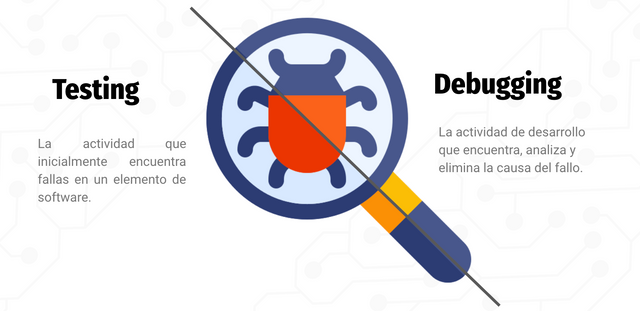

# Pruebas Funcionales

[figure not shown]

## **Pruebas unitarias:**

La primeras pruebas realizadas son denominadas **`“pruebas unitarias”`** en las cuales se realiza la verificación de la funcionalidad de los componentes de software de manera aislada.

## **Pruebas integración:**

Son las pruebas que deben hacer por medio del testeo de todos los componentes en conjunto, por lo cual a partir de las mimas se pueden conocer cómo se integran los componentes en un sistema.

Existen diferentes enfoques para las pruebas de integración, tales como:

- **`Top - Down:`** Las pruebas se realiza partiendo del componente principal en jerarquia, y posteriormente se van incorporando hacia abajo por la jerarquía de control.
- **`Bottom down:`** Las pruebas se realiza partiendo primero de los componentes de más bajo nive ly se crean componentes para simular a los componentes que los invocan.
- **`Integración Funcional:`** Las pruebas parten de los componentes necesarios para poder ver el funcionamiento de una función elegida del sistema.
- **`Big bang:`** Todos los componentes o sistemas están integrados simultáneamente, teniendo como la principal desventaja: es difícil rastrear la causa de las fallas.
- **`Incremental:`** Las pruebas incrementales se realizan teniendo en cuenta que los componentes se prueban uno o algunos a la vez, y se van agregando el restante de los componentes hasta que esten todos integrados y probados.

## **Pruebas de sistemas:**

Estas pruebas se realiza en función de los riesgos y especificaciones de los requisitos, procesos de negocio, casos de uso, historias de usuarios u otras descripciones realizadas. Las mismas tienen como objetivo probar el sistema en su conjunto y verificar si se cumplen todas las especificaciones funcionales y tecnicos.

## **Pruebas de aceptación:**

Este es el último nivel, en el cual el cliente valida si el desarrollo realizado cumple con lo solicitado y satisface las necesidades documentadas. Pero existen algunas variantes sobre este tipo de pruebas, tales como:

- **Aceptación de usuarios:** Las realizan los usuarios y gestores del aplicativo. Su objetivo es probar su funcionalidad.
- **Aceptación operacional:** En estas pruebas se comprueba por ejemplo: la facilidad de instalación, la seguridad, la recuperación de fallos, las tareas de mantenimiento y se realiza una comprobación de las vulnerabilidades de seguridad.
- **Aceptación contractual:** Se controla los criterios que se definieron en el contrato, el cumplimiento con estándares legales y de seguridad.
- **Alpha & beta:** Muchas veces las pruebas de aceptación del usuario no son posible ya que un software puede ser desarrollado para su posterior venta. En este caso existen dos tipos de pruebas:
  - **Alpha:** En este tipo de pruebas se realiza con usuarios potenciales y desarrolladores para que prueben el software.
  - **Beta:** El software una vez construido se envia a un conjunto de usuarios a fin de que lo prueben bajo condiciones reales, y en el caso detectar incidencias puedan enviarlas para poder ser corregidas. .Estos usuarios no tienen ningún contacto con los desarrolladores, a diferencia de las “alpha” que son desarrollados con el equipo de desarrollo.

# Pruebas No Funcionales

## Performance

Son las pruebas que permiten ver el rendimiento, carga y estrés. Aquí se evalúa como se comporta un sistema bajo una carga creciente y se documenta los tiempo de respuestas. Esta prueba intenta encontrar la falla ante una carga que excede lo permitido por el sistema procesar.

## Seguridad

Las pruebas de seguridad evalúan la CIA TRIAD (confidencialidad, integridad y disponibilidad) del software. Se realizan diferentes pruebas para evitar cualquier acceso no autorizado al código del software.

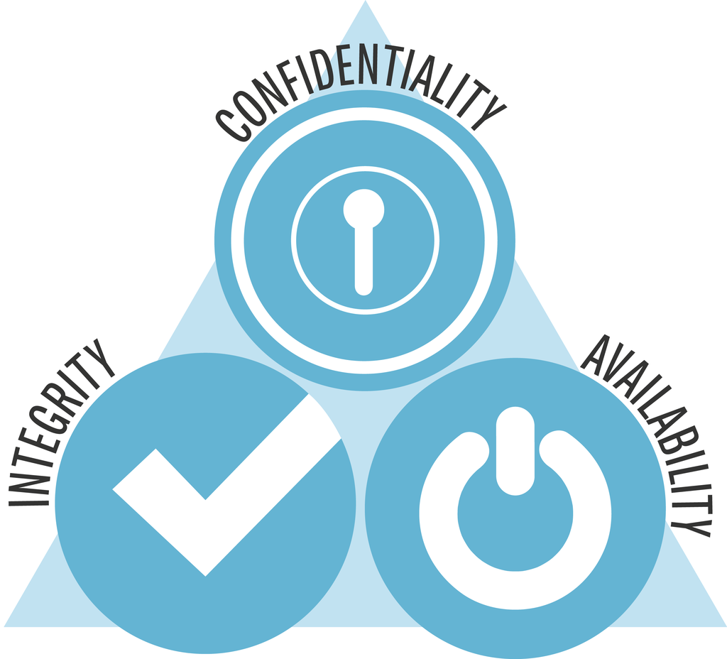

## Usabilidad

La parte de prueba de usabilidad de una metodología de prueba analiza el aspecto de usabilidad del software para el usuario final . La facilidad con la que un usuario puede acceder al producto constituye el principal punto de prueba.

La usabilidad de se define como la facilidad de las personas a interactuar con un software con el fin de alcanzar un objetivo con el mínimo esfuerzo requerido.

## Compatibilidad

La prueba de compatibilidad es una metodología que permite la prueba del software en diferentes sistemas operativos, plataformas de hardware, navegadores web, dispositivos móviles y otros software. Las pruebas deben validar el correcto funcionamiento como se espera en todas las diferentes combinaciones de hardware y software especificadas.

# Plan de pruebas

Un **`plan de prueba`** es un documento detallado que describe la estrategia de prueba, los objetivos, los recursos necesarios, el cronograma y los criterios de éxito una pieza de software específica. El objetivo principal, por supuesto, **`es descubrir defectos`** que pueda hacer que el software no actúe como se esperaba o que brinde una mala experiencia a sus usuarios.

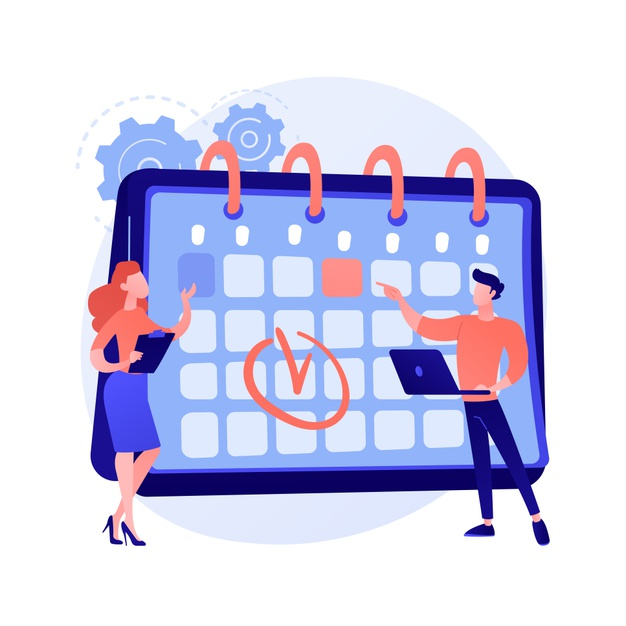

## ¿Cuales son los beneficios de realizar un plan de pruebas?

- 📍 Entender cómo se **realizará** el proceso de pruebas y cómo se **controlan** o **mitigan** los riesgos.
- ⌛Permite que el resto del equipo del proyecto puedan **conocer** cuáles son los **alcance** de las pruebas y el **tiempo** que se desarrollaran las mismas.
- 👥 Definir cuales son las **funciones y responsabilidades** de cada miembro del equipo, también proporciona cuales son los requisitos que son esenciales para llevar a cabo el proceso de prueba.
- 📆 El plan de prueba permite proporcionar un **cronograma para las actividades** de prueba, definiendo una estimación aproximada del tiempo.
- 📣La planificación permite una **mejor comunicación con otros miembros** del equipo del proyecto y otras partes interesadas
- ✔️Asegurar la calidad del entregable a realizar al cliente.

## Datos para registrar en un plan de pruebas:

| Concepto | Descripción |
| --- | --- |
| 1. | **iD Plan de prueba:** |
| 2. | **Introducción:** |
| 3. | **Elementos de prueba:** |
| 4. | **Alcance:** |
| 5. | **Fuera del alcance:** |
| 6. | **Criterio de aceptación:** |
| 7. | **Calendario:** |
| 8. | **Criterio de suspensión:** |
| 9. | **Entregables:** |
| 10. | **Tarea de pruebas:** |
| 11. | **Ambientes:** |
| 12. | **Responsabilidades:** |
| 13. | **Recursos:** |
| 14. | **Riesgos:** |

## Datos para registrar en un documento de caso de prueba

| Concepto | Descripción |
| --- | --- |
| 1. | **iD Caso de prueba:** |
| 2. | **Requisito Previo:** |
| 3. | **Pasos de prueba:** |
| 4. | **Resultados esperados:** |
| 5. | **Resultados reales:** |
| 6. | **Resultados Final:** |
| 7. | **Comentarios:** |
| 8. | **Prioridad:** |
| 9. | **Vencimiento:** |
| 10. | **Modulo: Cual es el modulo o componente sobre el que se va realizar la prueba. |
| 11. | **Tipo:** |
| 12. | **Responsable:** |

# RBT - Pruebas basadas en Riesgos

RBT - Pruebas basadas en riesgos (Risk-based testing) tienen que:

1. Identificar los riesgos.
2. Determinar cuál es la probabilidad.
3. Priorizar los módulos de software.
4. Planificar, diseñar y ejecutar actividades de prueba de acuerdo con la priorización de los módulos.
5. Supervisar y revisar los riesgos

El esfuerzo se asigna proporcionalmente al nivel de riesgo.

Los riesgos más importantes se prueban primero, siempre teniendo en cuenta de que se pueda realizar y tener todos los componentes entregados para sus pruebas.

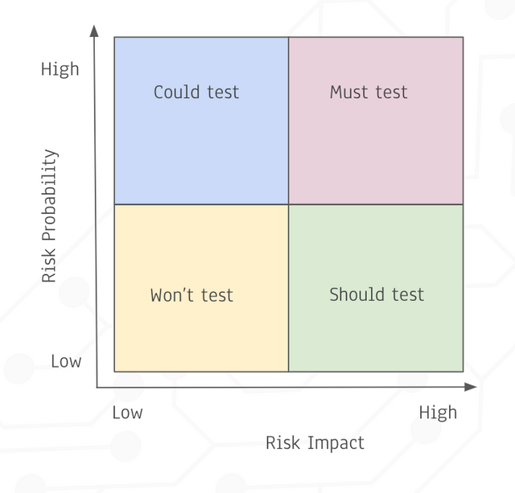

# Tecnicas de testing

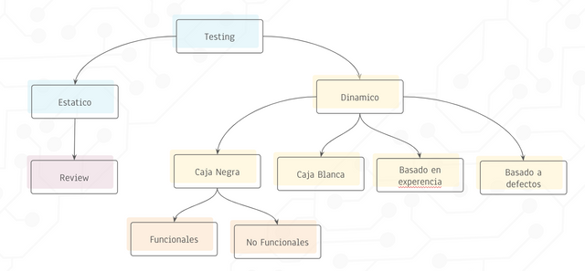

## Testing Estatico

Son técnicas de testing para detectar defectos sin ejecutar código.

Revisiones: Dentro de esta técnica tenemos el examen de artefactos de software para buscar errores tales como características faltantes, requisitos ambiguos, fallas de diseño, etc.

Por lo cual permite ahorrar tiempo en fases posteriores del desarrollo, debido a esto permite disminuir los costos .

## Testing Dinamico

El análisis dinámico requiere la ejecución del código y permite observar el funcionamiento del software y comparar los resultados.

## Functional Testing

Las pruebas funcionales consisten en comprobar si los componentes desarrollados cumplen con las funcionalidades documentadas en requisito funcionales.

Estas pruebas toman como referencia las especificaciones funcionales de un componente y se verifica si el comportamiento es el esperado.

Se utilizan métodos de prueba de caja negra.

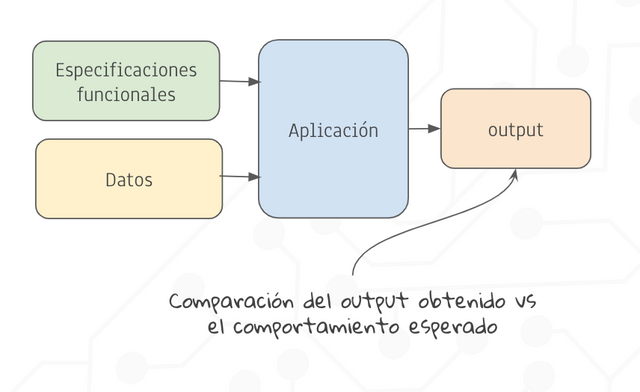

## Non-functional Testing

Son las pruebas no funcionales que permiten medir las características de los sistemas, tales como tiempos de respuesta para las pruebas de rendimiento. Estas pruebas nos permiten conocer si existe algún riesgo o acción no esperada en un entorno productivo.

Tipo de pruebas no funcionales: * Pruebas de carga * Pruebas de rendimiento * Pruebas de volumen * Pruebas de configuración * Pruebas de seguridad * Pruebas de resistencia * Pruebas de recuperación

## Structural Testing

El testing estructural denominado “caja blanca” es la prueba sobre el funcionamiento interno y la estructura de una pieza de software. Este tipo de testing se basa en el diseño interno y la implementación del software Alguno de los tipos de pruebas estructurales son:

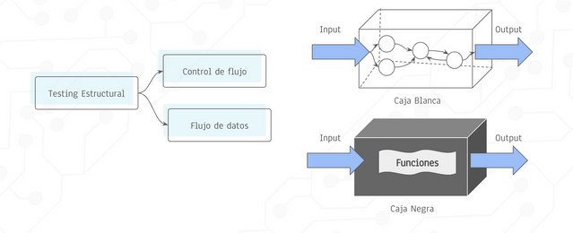

## Basado en la experiencia

El testing basado en la experiencia son pruebas que derivan de las habilidades y conocimiento que posee el tester, este tipo de pruebas permite que bajo la experiencia de la persona pueda predecir cuales son los errores que pueden encontrarse.

Para lo cual se debe realizar una lista con los posibles defectos y a partir de los cuales diseñar las pruebas.

## Basado en defectos

Esta técnica de prueba es basada en defectos, y los casos de prueba se derivan sobre la base de defectos.

Las pruebas se diseñan a partir de una categoría de defecto específica conocida como taxonomía de defectos.

Las taxonomías de defectos son listas categorizadas de defectos que pueden incluir listas de tipos de defectos, causas raíz, síntomas de falla y otros datos relacionados con defectos.

- Taxonomía informal de defectos
- Taxonomía específica de la industria / aplicación
- Taxonomía formal de defectos

Ejemplos: * Largo de los input no esta validado * Caracteres especiales no fueron validados * Fechas inválidas no fueron alertadas * URLs invalidas.

## Re-testing y Regression Testing

Las pruebas de regresión o regression testing se utilizan para validar si la aplicación existente todavía funciona como se esperaba después de haber sido actualizada o modificada. Es necesario conocer si algo en el funcionamiento ha cambiado o el software permanece sin fallas.

Como realizarlo? 1. Se puede utilizar la automatización de las pruebas con casos de pruebas reutilizables. 2. Se pueden analizar cuales son los módulos o las partes del software que pueden verse alterados o afectados por la implementación. 3. Definir cuál es el tiempo que va utilizar para realizar este tipo de pruebas.

# Testing Automation

> La **automatización de pruebas** consiste en el uso de software para ejecutar pruebas. Por lo cual La automatización de pruebas permite incluir pruebas repetitivas.

Los beneficios de automatizar pruebas son:

1. Se reduce el trabajo repetitivo
2. Ahorro de costos.
3. Cada caso de prueba se puede automatizar
4. La automatización puede ser realizadas para nuevas funciones
5. La automatización de pruebas permite ejecutar más casos de prueba
6. Respuesta rápida a los desarrolladores
7. Informe de defectos personalizado
8. Encontrar defectos omitidos por pruebas manuales

## ¿Qué es Selenium?

**Selenium** es un framework de automatización web de codigo abierto que te permite ejecutar test en navegadores web, en esta clase vamos a utilizar **Python**

Algunas ventajas que tenemos al utilzar Selenium: * Los script se pueden generar en varios lenguajes de programación como Java, C#, PHP y en esta clase vamos a utilizar **Python** * Ejecturar estas pruebas en navegadores como firefox, chorme, safari y opera. * Utilizar sistemas operativos como: Windows, Mac o Linux. * Integraciones con Jenkins y docker.

Se puede utilizar para… * Aceptación / pruebas funcionales * Reproducir errores * Examen de la unidad * Pruebas de regresión

Los navegadores más conocidos compatibles con la utilización de Selenium son: * Explorer * Mozilla Firefox * Google Chrome * Safari

[figure not shown]

A continación te dejo los pasos para poder realizar una prueba con **Selenium** en python 🐍

1. Vamos a instalar el paquete de **selenium**

```
!pip install selenium
```

2. Necesitamos instalar el ejecutable denominado chromedriver, este ejecutable va a variar en base al sistema operativo y la version de chrome que tengamos instalado: https://chromedriver.chromium.org/downloads
3. Vamos importar python y pandas para hacer las pruebas necesarias.

```
from selenium import webdriver
import pandas as pd

# Ubicación del ejecutable
driver = webdriver.Chrome("/chromedriver")

# Ejecutamos una pagina de inicio
driver.get("https://google.com")
```

### Formas de identificar a un elemento en el DOM

Selenium Webdriver API admite múltiples formas de identificar elemento

| Identificación | Sintaxis |
| --- | --- |
| ID | driver.find_element_by_id() |
| nombre | driver.find_element_by_name() |
| ClassName | driver.find_element_by_class_name() |
| TagName | driver.find_element_by_tag_name() |
| XPath | driver.find_element_by_xpath() |
| CSS Selector | driver.find_element_by_class_name() |

Qué es XPath? **XPath** se define como XML path (Ruta XML). Esta estcutructar permite encontrar un elemento de la pagina web.

La sintaxis estándar para crear XPath es:

- Xpath=//nombreEtiqueta[@atributo='valor']
- **//:** Selecciona el nodo actual
- **Nombre Etiqueta:** Nombre de la etiqueta del nodo en particular
- **@:** Seleccionar atributo.
- **atributo:** nombre de atributo del nodo.
- **valor:** valor del atributo.
- Tipos de path
- **XPath absoluto**: Ejemplo de xpath absoluto `/html/body/div[4]/div/div[3]/article[1]/div[2]/a`
- **XPath relativo**: Ejemplo de xpath absoluto `//*[@id="1442737"]/div[2]/a`
4. Ingresemos a la pagina `https://tuquejasuma.com/``

```
driver.get("https://tuquejasuma.com/")
element = driver.find_element_by_id("searcher")
element.send_keys("Banco Nacion")
driver.find_element_by_xpath('//*[@id="breadcrum-search"]/form/button').click()
```

[^1]: [GitHub Datos de miercoles](https://github.com/cienciadedatos/datos-de-miercoles)

Comment on this article